# EDA-Capstone(Modeling)

Rohit Jain

February 22, 2019

## Description

The goal of this project is just to display working with the data and that I am on track to create me prediction algorithm.

## Table of Content

1. Demonstrating data download and loading.
2. Summary statistics about the data sets.
3. Basic Plots.
4. Plans for creating a prediction algorithm.

## 1. Demonstrating data download and loading:

I have downloaded the data for the course page to my working directorty and unzip the same, thereafter using the below self written function in a supported R file. I have loaded the data in the working environment with varibale names as follows:

Data Declaration

| Data | Variable Name |
| --- | --- |
| NEWS | newsdt |
| BLOGS | blogdt |
| Twitter | twitdt |

### loading data:

```r
source(paste0(getwd(),'/readfile.R'))
newsdt <- readData("en_US.news.txt")
blogdt <- readData("en_US.blogs.txt")
twitdt <- readData("en_US.twitter.txt")
```

## 2. Summary statistics about the data sets:

In this part of the report I am caculating the size of the respective files loaded in the workng environment using the “objSize” function written in the supported R file.

```r
library(knitr)
tempSize <- as.data.frame(matrix(c("NEWS","BLOGS","TWITTER",
                                    "objSize(newsdt)","objSize(blogdt)","objSize(twitdt)",
                                    objSize(newsdt),objSize(blogdt),objSize(twitdt)
                                  ),
                                 ncol = 3,
                                 byrow = FALSE
                                )
                         )
names(tempSize) <- c("DATA","FUNCTION CALL","SIZE")
kable(tempSize,caption = "Data file size table",align = "c")
```

Data file size table

| DATA | FUNCTION CALL | SIZE |
| --- | --- | --- |
| NEWS | objSize(newsdt) | Size of file is 1.917 MB |
| BLOGS | objSize(blogdt) | Size of file is 24.77 MB |
| TWITTER | objSize(twitdt) | Size of file is 30.378 MB |

Now I will be counting the words and lines in the given documents using the “tokenData” function written in the supported R file.

```r
library(knitr)
source(paste0(getwd(),'/readfile.R'))
newsT1 <- tokenData(newsdt,1)
blogT1 <- tokenData(blogdt,1)
twitT1 <- tokenData(twitdt,1)
newsLine <- tokenData(newsdt,"l")
blogLine <- tokenData(blogdt,"l")
twitLine <- tokenData(twitdt,"l")

tempCount <- as.data.frame(matrix(c("NEWS","BLOGS","TWITTER",
                                    sum(newsT1$n),sum(blogT1$n),sum(twitT1$n),
                                    nrow(newsLine),nrow(blogLine),nrow(twitLine)
                                    ),ncol=3,byrow = FALSE))
names(tempCount) <- c("DATA","Word-Count","Line-Count")
kable(tempCount,caption = "Word and line count table",align = "c")
```

Word and line count table

| DATA | Word-Count | Line-Count |
| --- | --- | --- |
| NEWS | 262200 | 7725 |
| BLOGS | 3761217 | 89928 |
| TWITTER | 2977299 | 236014 |

## 3. Basic Plots:

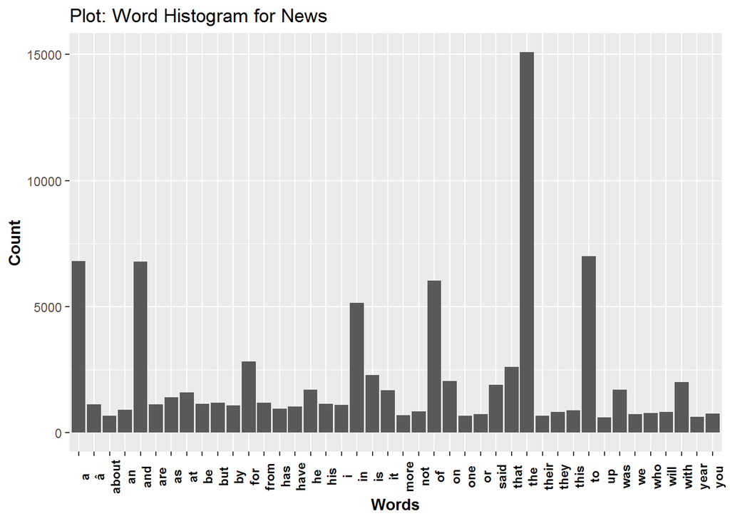

```r
ggplot(newsT1 %>% filter(n>600),aes(wd,n)) + geom_bar(stat = "identity") +
    labs(title = "Plot: Word Histogram for News", x = "Words", y = "Count")+
    theme(axis.text.x = element_text(angle = 90, face = "bold", colour = "black"),
          axis.title.x = element_text(face = "bold",colour = "black"),
          axis.title.y = element_text(face = "bold",colour = "black"))
```

## 4. Plans for creating a prediction algorith:

I will be using the Katz’s back-off generative n-gram language model that estimates the conditional probability of a word given its history in the n-gram. It accomplishes this estimation by backing off through progressively shorter history models under certain conditions. By doing so, the model with the most reliable information about a given history is used to provide the better results.

### NOTE: the supported R file “readfile.R” can be located at https://github.com/Rohit1310/CourseraCapstone